# Trading and investment account summary

# For 2020-09-04

Summary text: The equity value of my live trading portfolio changed by 0.27 % (US$ 91.82 ) from US$ 34622.95 to US$ 34714.77 today ( 2020-09-04 ). The trading proceeds in my live account were US$ 1015.1 . The book proceeds in my portfolio changed from US$ 1611.82 to US$ 688.54

## Portfolio

The below table shows the current positions in the live account as well as their current and total performance. “book_proceed” indicates the unrealized profit in that position.

| symbol | close | closePerc | Total_Change_close | entry_price | position | position_size | entry_position | totalPerc | book_proceed | sector |
| --- | --- | --- | --- | --- | --- | --- | --- | --- | --- | --- |
| QQQ | 283.47 | -1.3 | 112.2 | 284.93 | -30 | -8504.10 | -8547.80 | 0.51 | 43.7 | Miscellaneous |
| KWEB | 69.76 | 0.05 | 3.5 | 70.13 | 100 | 6976.00 | 7012.61 | -0.52 | -36.61 | Miscellaneous |
| LULU | 361.41 | -4.36 | -230.44 | 367.71 | 14 | 5059.74 | 5147.94 | -1.74 | -88.2 | Retail Trade |
| TSLA | 417.93 | 2.69 | 87.45 | 370.23 | 8 | 3343.45 | 2961.80 | 11.41 | 381.64 | Consumer Durables |
| GOOG | 1590.01 | -3.18 | -104.42 | 1624.99 | 2 | 3180.02 | 3249.98 | -2.2 | -69.96 | Technology Services |
| BRK.B | 218.25 | 0.09 | 2.6 | 199.94 | 13 | 2837.25 | 2599.25 | 8.39 | 238 | Finance |
| SQ | 146.40 | -4.23 | -97.05 | 146.54 | 15 | 2196.00 | 2198.11 | -0.1 | -2.11 | Technology Services |
| DBX | 19.76 | -3.94 | -81 | 20.06 | 100 | 1976.00 | 2005.72 | -1.5 | -29.72 | Technology Services |
| SEAS | 21.06 | 0.14 | -2.7 | 19.05 | -90 | -1895.40 | -1714.50 | -9.54 | -180.9 | Consumer Services |
| CAKE | 31.21 | -0.64 | -10 | 24.53 | 50 | 1560.50 | 1226.28 | 21.42 | 334.22 | Consumer Services |
| USL | 15.22 | -3.55 | -56 | 15.74 | 100 | 1522.00 | 1573.99 | -3.42 | -51.99 | Miscellaneous |
| GOLD | 29.05 | -0.72 | -10.5 | 28.78 | 50 | 1452.50 | 1438.95 | 0.93 | 13.55 | Non-Energy Minerals |
| AAPL | 120.90 | -0.02 | 0.2 | 120.04 | -10 | -1209.00 | -1200.40 | -0.71 | -8.6 | Electronic Technology |
| INDA | 33.40 | -0.51 | -5.1 | 33.10 | 30 | 1002.00 | 993.00 | 0.9 | 9 | Miscellaneous |
| SLV | 25.04 | 1.25 | 10.85 | 23.40 | 35 | 876.40 | 819.12 | 6.54 | 57.28 | Miscellaneous |
| MIK | 10.50 | 8.42 | 65.2 | 9.19 | 80 | 840.00 | 735.18 | 12.48 | 104.82 | Retail Trade |
| ABT | 104.16 | -1.27 | -10.72 | 107.98 | 8 | 833.28 | 863.86 | -3.67 | -30.58 | Health Technology |
| XLI | 77.87 | 0.26 | 2 | 77.64 | 10 | 778.70 | 776.40 | 0.3 | 2.3 | Miscellaneous |
| TPR | 14.57 | -1.02 | -6.45 | 14.96 | 43 | 626.51 | 643.48 | -2.71 | -16.97 | Retail Trade |
| MGM | 23.52 | 1.95 | 11.25 | 22.04 | 25 | 588.00 | 551.12 | 6.27 | 36.88 | Consumer Services |
| RVLV | 20.81 | -2.21 | -11.75 | 18.56 | 25 | 520.25 | 463.98 | 10.82 | 56.27 | Retail Trade |
| NFLX | 515.77 | -1.9 | -9.98 | 486.00 | 1 | 515.77 | 486.00 | 5.77 | 29.77 | Consumer Services |
| UNM | 19.89 | 8.22 | 37.75 | 19.21 | 25 | 497.25 | 480.15 | 3.44 | 17.1 | Finance |
| EPHE | 25.82 | 1.33 | -6.12 | 25.72 | -18 | -464.76 | -463.03 | -0.37 | -1.73 | Miscellaneous |
| IAU | 18.46 | 0.33 | 1.5 | 18.96 | 25 | 461.50 | 473.92 | -2.69 | -12.42 | Miscellaneous |
| CAT | 148.16 | 0.93 | 4.11 | 142.04 | 3 | 444.48 | 426.12 | 4.13 | 18.36 | Producer Manufacturing |
| PALL | 215.83 | 1.03 | 4.38 | 216.38 | 2 | 431.66 | 432.76 | -0.25 | -1.1 | Miscellaneous |
| V | 204.56 | -2.07 | -8.66 | 194.66 | 2 | 409.12 | 389.33 | 4.84 | 19.79 | Finance |
| UPWK | 13.94 | -4.72 | -17.25 | 14.55 | 25 | 348.50 | 363.68 | -4.36 | -15.18 | Technology Services |
| PPLT | 84.80 | 1.71 | 5.7 | 89.44 | 4 | 339.20 | 357.75 | -5.47 | -18.55 | Miscellaneous |
| CCL | 18.53 | 5.4 | 16.15 | 15.39 | 17 | 315.01 | 261.64 | 16.94 | 53.37 | Consumer Services |
| LMND | 47.26 | -6.88 | -17.45 | 71.86 | 5 | 236.30 | 359.29 | -52.05 | -122.99 | Finance |
| CRUS | 58.30 | -0.07 | -0.12 | 71.60 | 3 | 174.90 | 214.81 | -22.82 | -39.91 | Electronic Technology |

| symbol | close | closePerc | Total_Change_close | entry_price | position | position_size | entry_position | totalPerc | book_proceed | sector |
| --- | --- | --- | --- | --- | --- | --- | --- | --- | --- | --- |
| Summary | NA | NA | -320.87 | NA | 968 | 52415.55 | NA | 1.31 | 688.5386 | NA |

[interactive chart not shown]

The performance of my live stock portfolio/trading account vs. my paper trading account and the benchmark ‘SPY’, the US large cap stock market index ETF in percent since June 09 2020.

[interactive chart not shown]

This plot shows a summary of the trading activity on that day. Above 0 is a gain, below is a loss. TRUE indicated live trading account, FALSE is paper trading. A buy side trade is a closed short sale trade and sell side trade is a closed long trade.

[interactive chart not shown]

My current portfolio sorted by sectors. The plot reads clock-wise. Positions below 0 are short positions. Clicking a slice of the pie chart directs to marketwatch.com for further information.

[interactive chart not shown]

These two plots indicate the composition of my portfolio and the change of it over the past week.

[interactive chart not shown]

The inner circle is Monday, the outer circle is Friday.

[interactive chart not shown]

The colors in this plot indicate the daily percentage change of each stock in my portfolio.

[interactive chart not shown]

I classified the stocks in my portfolio by sector. The area represents the size of the position in the portfolio. Long postions

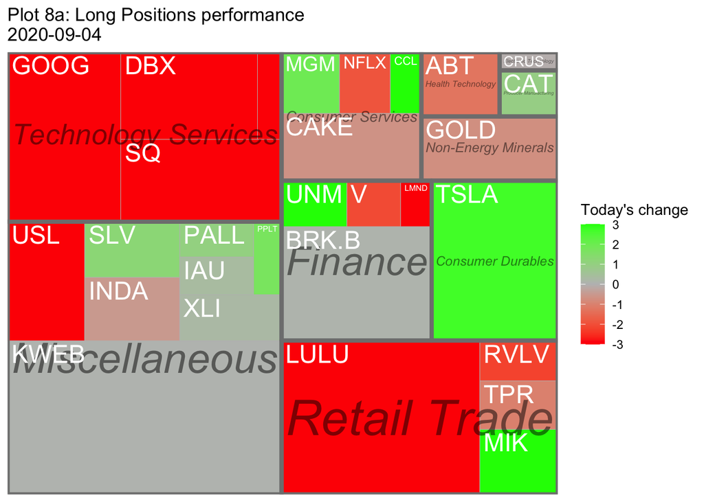

Short postions

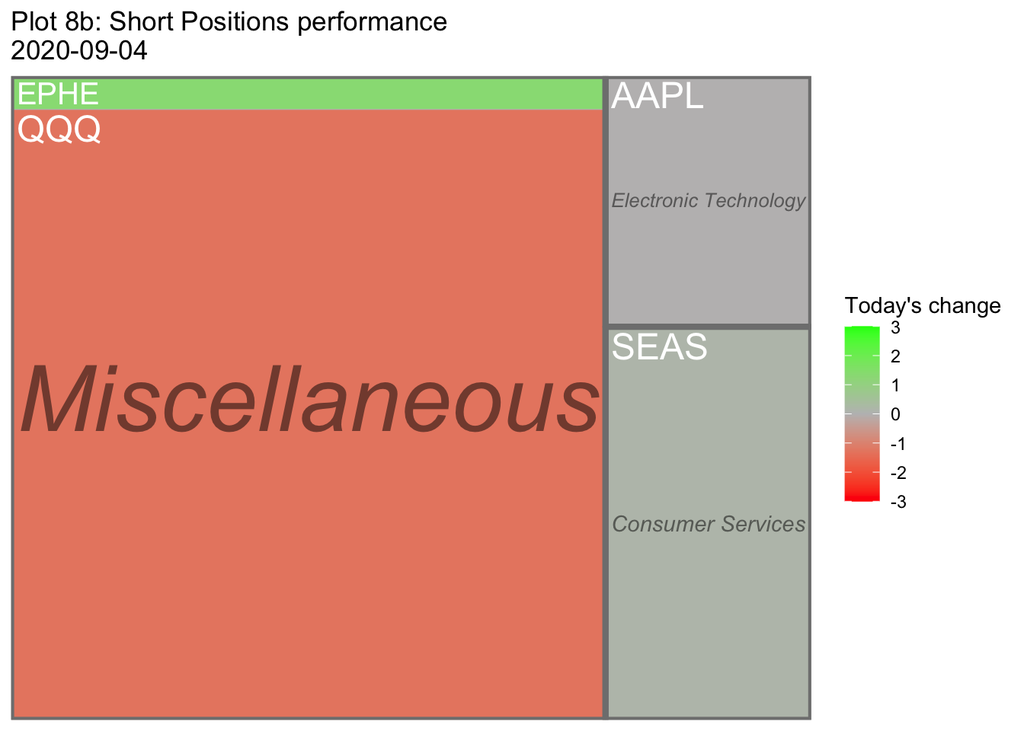

S&P 500 stocks colored by last day performance.

Outliers skew the colors, making the other stocks look pale. I restricted the colors to max of 3 and -3% change. Every stock having higher or lower than 3% change has the same color.

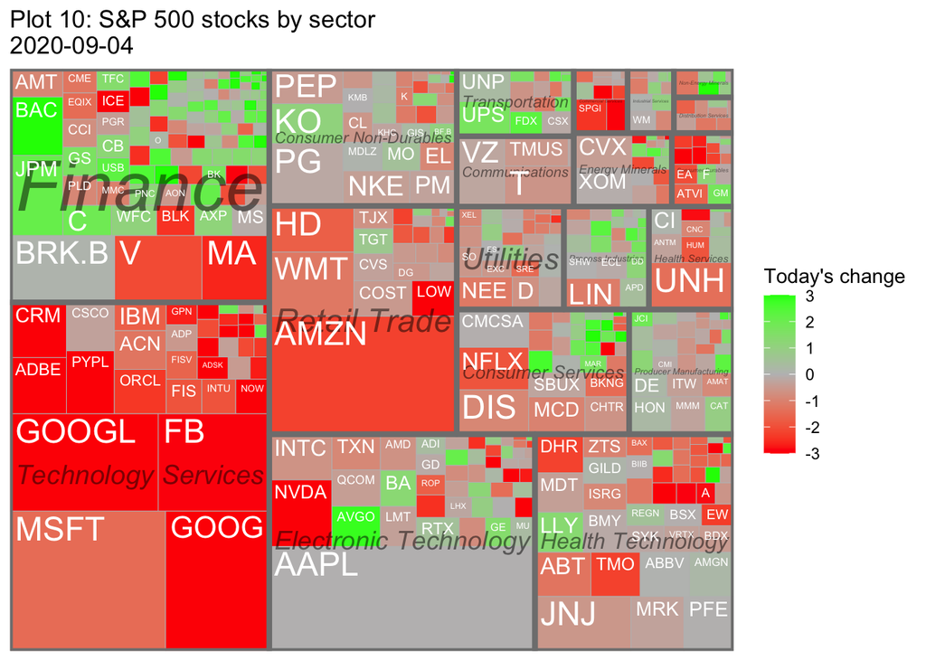

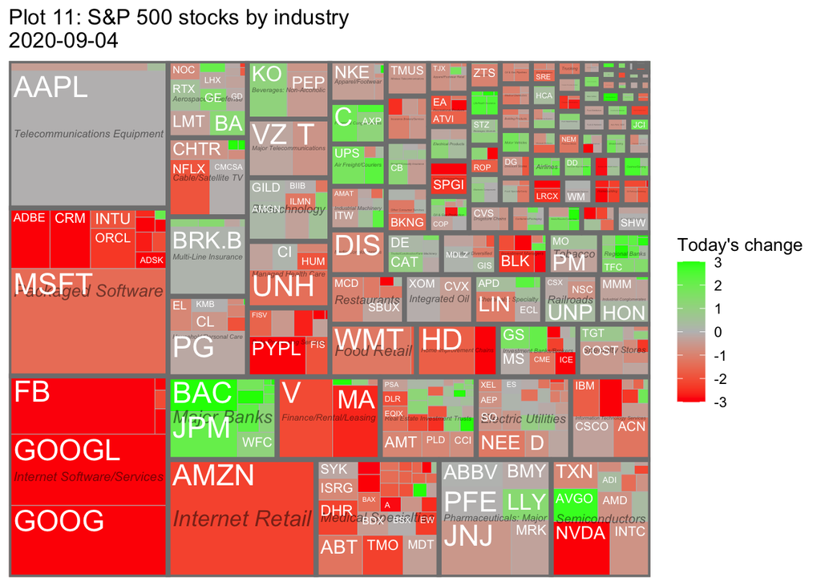